# Exploring Transmission Expansion in an RE future in India

Shubhangi Gupta, Aditi Jackson, David Robinson

2024-03-29

# Introduction

## Motivation, Relevance, Objectives

As one of the world’s fastest growing emerging economies, India’s demand for electricity is increasing every year - fueled by newly electrified homes, growing industry, urbanization, rising income levels, a higher demand for cooling and in a low carbon future - the electrification of end use sectors like industry and transport. To address this demand, the country plans to almost double its power capacity to 900 GW by 2030, up from 427 GW today. [Source](https://energy.economictimes.indiatimes.com/news/power/indias-power-demand-projected-to-reach-366-gw-by-2030-capacity-expansion-to-900-gw-targeted/106971394). At the same time, as a signatory of the Paris Agreement, India has committed to reducing its national emissions to net zero by 2070, with an intermediate target of transitioning 50% of its electric generation capacity to clean sources by 2030 as part of its NDC to the UNFCCC. [Source](https://unfccc.int/sites/default/files/NDC/2022-08/India%20Updated%20First%20Nationally%20Determined%20Contrib.pdf). In line with this growing demand for electricity and simultaneous need to decarbonize, India has announced a complementary target of achieving 500 GW of renewable energy capacity by 2030. [Source](https://www.reuters.com/article/idUSKCN1TQ1QW/). However, to ensure that this new clean energy translates into emissions reductions, integrating such high levels of variable renewable energy (VRE) into the electric system requires a concurrent expansion and modernisation of the grid, so that issues around connecting new RE capacity to load centres, power flow management and congestion, and managing higher load volumes do not impede the clean energy transition.

With this context in mind, in this study, we aim to: Explore how India’s transmission capacity has changed over the last several years and thus forecast it based on historical trends. This would allow us to identify what capacity it will reach in 2030 in a “business as usual” scenario. We then compare our finding to what is needed by 2030 to integrate the additional 500 GW of RE into the grid as assessed in the literature, to highlight thr gap between current trends and what is needed.

## Dataset information and methods

For this study, we used data on the line length (in ckm) of transmission lines installed in India, taken from the “India Climate and Energy Dashboard (ICED)” developed by the Government of India’s inhouse think tank - the NITI Aayog. The data is monthly and extends from April 2015 to January 2024 and represents the length of new transmission lines (in ’00 kms) added across the country in each month during this timeframe. While line length does not reflect voltage levels and different types of transmission and distribution, the portal from which we acquired the data clearly states that this length refers to transmission only. We also explored the additions to transmission capacity by voltage to determine if the declining trend could be attributed to the addition of higher efficiency voltage lines but found, based on research from Indian think-tank Prayas, that this is not the case - rendering line length a simple yet effective metric to explore how thr transmission grid has expanded in India over the last decade. [Source](https://indiatransmission.org/transmission-line). However, forecasting annual additions was misleading as it had a negative declining trend overtime while we were forecasting transmission growth in India. Upon reflection, we decided to transform annual additions to cumulative line length in each time period instead which allowed us to represent how total transmission capacity has grown over time more accurately. Plotting cumulative line capacity over time showed a clear increasing trend.

The original dataset included two columns of interest - additional line length (ckm) in each month, and month/year of completion. In order to create a time series dataset of total line length in each month, we wrangled it using the following process:

Stage 1: Wrangling and methods (1) Importing the dataset, subsetting it to only retain these two columns of interest, and renaming them to simpler names. Packages used were tidyverse, dplyr, lubridate, readxl, ggplot2, forecast, Kendall, tseries, smooth, readr, zoo, cowplot, kableExtra (2) Checking if there were any NAs (there weren’t). (3) Splitting the “month/ year of completion column” that was a string into the month and year separately, converting the year from two digits to four digits (ex: “15” to “2015”), pasting that back with the month column separated by a “-” and then using lubridate to convert it into a date object. (4) Using the group_by(Date) function to add up all the capacity additions in the same month - that in the original dataset were broken up across multiple rows based on the regions of India that they occurred in (we only consider total nation-wide capacity and do not look at this data’s breakup across states/ regions). (5) Using the cumsum() function to sum the line length of the previous month’s total capacity (calculated) to the current month’s capacity addition (original data). This gave us a dataset with two columns: Date and total transmission line length (ckm) until that month. (6) Plotting these two columns along with an lm line to check the trend. This concluded the first stage of wrangling the data to acquire our final dataset to be used for the analysis.

## Data Structure

Data Structure Summary - NITI Aayog

| Detail | Description |
| --- | --- |
| Data Source | India Climate and Energy Dashboard |
| Retrieved from | https://iced.niti.gov.in/energy/electricity/transmission/transmission-lines |
| Variables Used | Transmission Line Length |
| Units Used | ckm (’00 km) |
| Data Range | April 2015 - January 2024 |
| Minimum Value | 737 ckm (April 2015) |
| Maximum Value | 167889 ckm (January 2024) |

## Data Wrangling & initial plot

```
## [1] TRUE
```

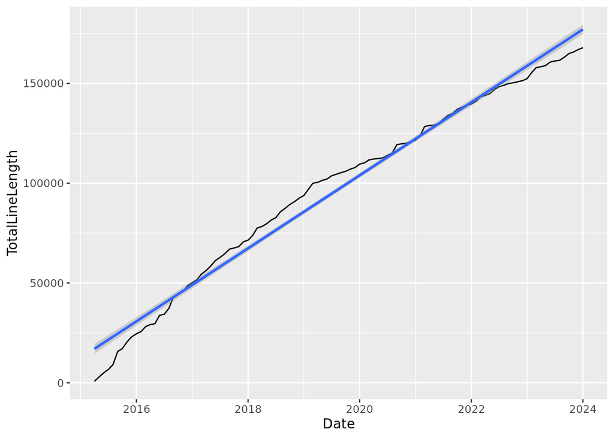

# Analysis

## Plots

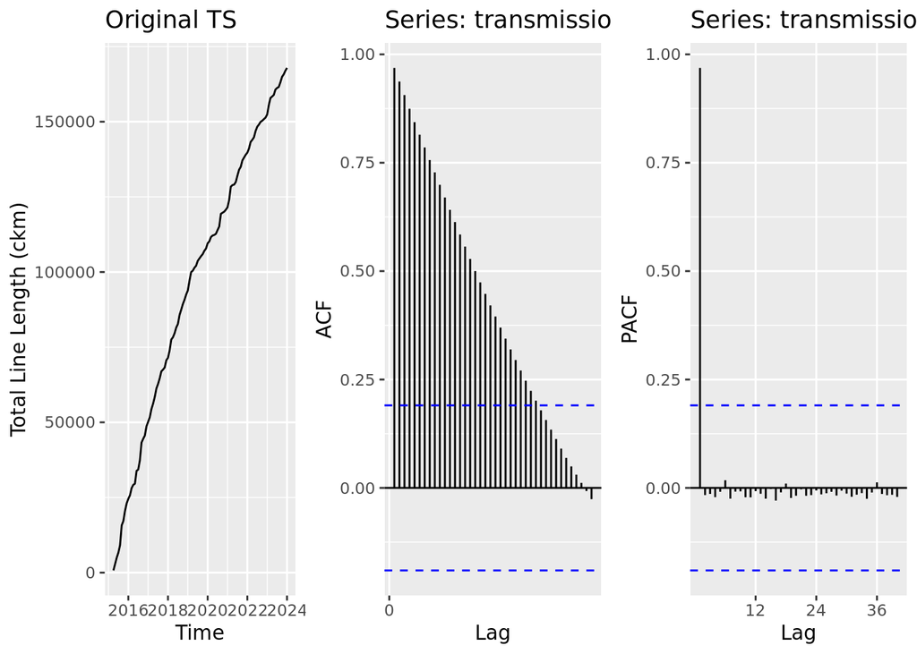

## Decomposition

The series was then decomposed into observed, trend, seasonality, and residuals. The observed and trend components both increase similarly over time. However, the seasonal component is not representative of the dataset. Upon further inspection, we observed that the seasonality was too uniform in magnitude and may not be part of the dataset. While there may be some seasonality due to construction start and end dates for transmission projects (e.g. before and after Monsoon Season), it is more likely that the decompose function in R is forcing a seasonal component that does not exist within the data. As such, we did not de-season the data and instead chose to fit models that could handle seasonality (see below). The residuals looked fairly random, so we did not see the need for further manipulation before fitting models.

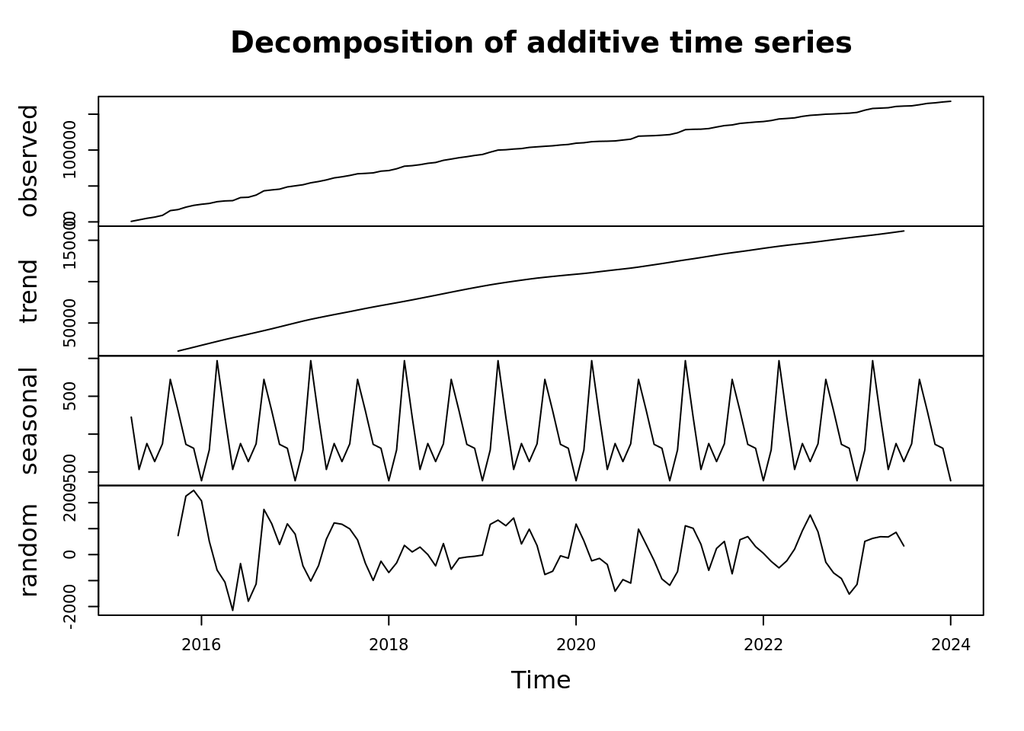

## Statistical Tests

```
## Score =  416 , Var(Score) = 1050.667
## denominator =  416
## tau = 1, 2-sided pvalue =< 2.22e-16
## NULL
```

```
##
##  Augmented Dickey-Fuller Test
##
## data:  transmission_ts
## Dickey-Fuller = -3.2942, Lag order = 4, p-value = 0.07586
## alternative hypothesis: stationary
```

## Model Fitting & Forecasting

We fit three models to our transmission time series data: Seasonal ARIMA (SARIMA), TBATS, and Neural Network.

### SARIMA - Model and Forecast

We chose to start with the SARIMA model given its relative simplicity and ability to handle seasonality. To fit the SARIMA model, we used the auto.arima() function to generate the order of parameters. The function produced the following: p = 0, d = 2, q= 1, P = 1, D = 0, Q = 1. The non-seasonal parameters suggest no autoregressive component (p=0), 2 degrees of differencing (d=2), and a moving average component (q=1). The seasonal part of the model suggests that there is some seasonal autoregression (P=1), no differencing, and some seasonal moving average (Q=1). After fitting the SARIMA model, we used the forecast function to create a 10-month forecast and compared the values with those in our testing data. The model appears to fit well based on visual inspection. An accuracy table is provided below as well as a discussion of the results. We then created a 7-year forecast (from February 2024 to March 2030) to ascertain a value for transmission build-out by 2030.

```
## Series: transmission_ts_training
## ARIMA(0,2,1)(1,0,1)[12]
##
## Coefficients:
##           ma1    sar1     sma1
##       -0.9451  0.8338  -0.5295
## s.e.   0.0320  0.1292   0.2064
##
## sigma^2 = 1090869:  log likelihood = -788.27
## AIC=1584.53   AICc=1584.98   BIC=1594.7
```

```
## Series: transmission_ts_training
## ARIMA(0,2,1)(1,0,1)[12]
##
## Coefficients:
##           ma1    sar1     sma1
##       -0.9451  0.8338  -0.5295
## s.e.   0.0320  0.1292   0.2064
##
## sigma^2 = 1090869:  log likelihood = -788.27
## AIC=1584.53   AICc=1584.98   BIC=1594.7
##
## Training set error measures:
##                     ME     RMSE      MAE         MPE     MAPE       MASE
## Training set -88.36536 1016.884 760.9757 -0.09538527 1.445726 0.03940281
##                     ACF1
## Training set -0.01866278
```

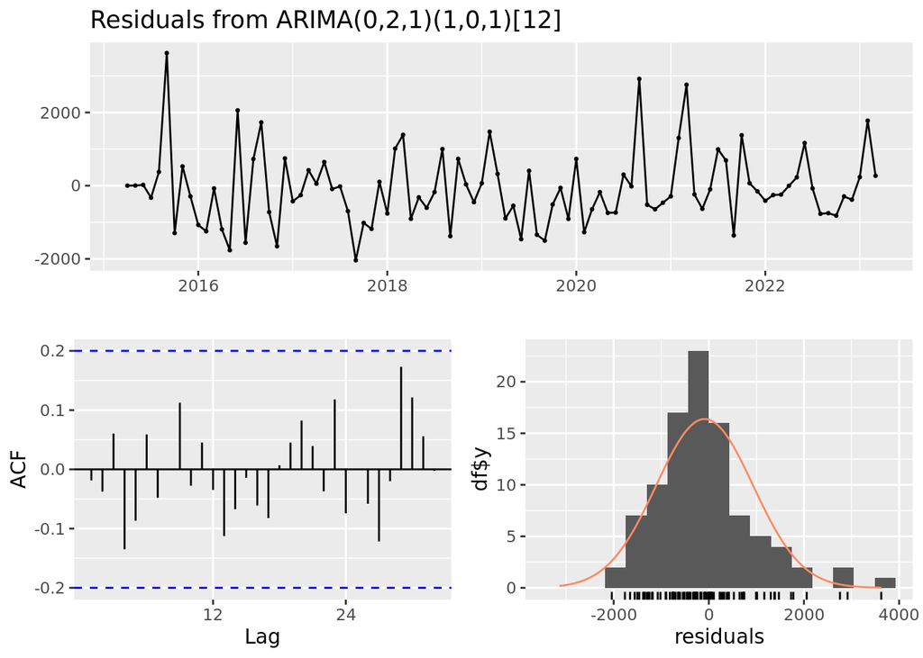

```
##
##  Ljung-Box test
##
## data:  Residuals from ARIMA(0,2,1)(1,0,1)[12]
## Q* = 9.0798, df = 16, p-value = 0.9101
##
## Model df: 3.   Total lags used: 19
```

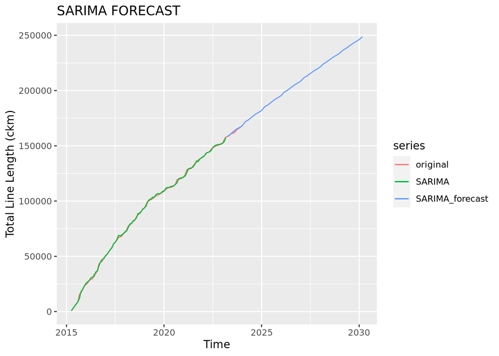

```
##                     ME     RMSE      MAE         MPE     MAPE       MASE
## Training set -88.36536 1016.884 760.9757 -0.09538527 1.445726 0.03940281
##                     ACF1
## Training set -0.01866278
```

### TBATS - Model and Forecast

TBATS was the next model we fit to our time series. Given the uncertainty around seasonality in our data, we opted for TBATS since the model can handle seasonal variation. We fit the model using the tbats() function from the forecast package. We then used the TBATS model to generate a forecast and compared the forecast to our original data. Again, we forecasted 7 years of values in order to obtain a value for transmission build-out by 2030. Upon inspection, the forecast compares favorably with the test values from our original data.

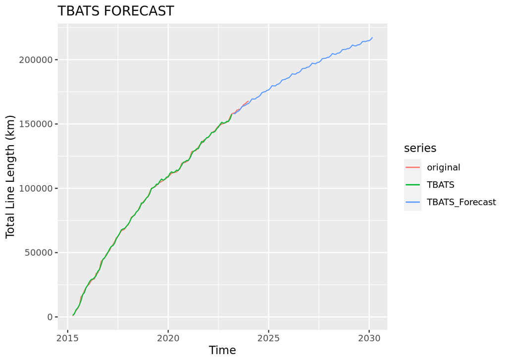

```
##                   ME     RMSE     MAE        MPE     MAPE       MASE
## Training set 13.7543 887.3142 685.352 -0.6353815 2.303935 0.03548707
##                     ACF1
## Training set -0.00187256
```

### Neural Network - Model and Forecast

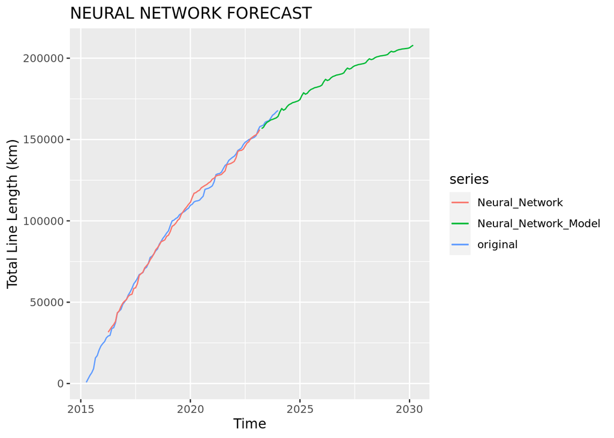

```
##                    ME     RMSE      MAE        MPE     MAPE      MASE      ACF1
## Training set 9.247711 2516.559 1982.304 -0.1809522 2.206077 0.1026424 0.8877641
```

## Checking Accuracy

Across the three models and forecasts that were run, we evaluated the accuracy of each model to understand the best fit. By Root Mean Squared Error or RMSE equal to 887, the best model is TBATS. By Mean Absolute Percentage Error or MAPE equal to 1.44, the best model is SARIMA. Additionally, we added a table to show various accuracy metrics in detail across SARIMA, TBATS, and NN models for detailed, quantitative comparison across a variety of accuracy measures.

```
## The best model by RMSE is: TBATS
```

```
## The best model by MAPE is: SARIMA
```

Forecast Accuracy Table

|  | ME | RMSE | MAE | MPE | MAPE | MASE | ACF1 |
| --- | --- | --- | --- | --- | --- | --- | --- |
| SARIMA | -88.36536 | 1016.8839 | 760.9757 | -0.09539 | 1.44573 | 0.03940 | -0.01866 |
| TBATS | 13.75430 | 887.3142 | 685.3520 | -0.63538 | 2.30393 | 0.03549 | -0.00187 |
| NN | 9.24771 | 2516.5592 | 1982.3042 | -0.18095 | 2.20608 | 0.10264 | 0.88776 |

# Summary and Conclusions

Our primary research question was “How does this compare to the transmission capacity needed in a net zero-aligned renewable-heavy future?”

```
##           Jan      Feb      Mar      Apr      May      Jun      Jul      Aug
## 2023                            158662.4 159416.7 160716.2 162063.3 163202.7
## 2024 168047.5 169927.2 171919.3 172707.5 173492.3 174731.8 176010.8 177116.7
## 2025 181935.7 183658.9 185475.7 186288.8 187099.1 188288.4 189510.7 190588.7
## 2026 195386.2 196978.8 198649.6 199483.5 200314.9 201462.4 202637.5 203692.2
## 2027 208471.8 209955.5 211504.5 212355.7 213204.8 214317.5 215453.1 216488.4
## 2028 221253.0 222646.1 224093.4 224959.0 225822.9 226906.6 228009.3 229028.4
## 2029 233780.6 235098.0 236460.6 237338.3 238214.5 239273.9 240349.3 241354.9
## 2030 246096.6 247350.9 248643.0
##           Sep      Oct      Nov      Dec
## 2023 164500.6 165430.6 166229.2 167067.2
## 2024 178354.8 179286.1 180107.8 180962.5
## 2025 191776.9 192709.3 193550.4 194418.9
## 2026 204838.8 205772.1 206629.3 207509.3
## 2027 217600.3 218534.4 219405.0 220294.6
## 2028 230111.4 231046.1 231927.9 232825.6
## 2029 242413.7 243349.0 244240.1 245144.4
## 2030
```

```
##           Jan      Feb      Mar      Apr      May      Jun      Jul      Aug
## 2023                            157945.4 158123.5 159441.2 160024.0 161347.2
## 2024 165922.1 167429.7 169427.4 169373.7 169447.2 170661.3 171141.5 172363.1
## 2025 176443.2 177854.6 179756.9 179608.7 179588.7 180710.0 181098.3 182228.8
## 2026 185865.9 187191.0 189008.0 188775.2 188671.3 189709.5 190015.4 191064.4
## 2027 194304.7 195552.7 197293.1 196984.5 196805.5 197769.4 198001.6 198977.5
## 2028 201862.4 203041.3 204713.2 204336.8 204090.5 204987.7 205153.9 206064.4
## 2029 208631.1 209748.0 211358.6 210921.4 210614.9 211452.4 211559.5 212411.3
## 2030 214693.0 215754.5 217310.2
##           Sep      Oct      Nov      Dec
## 2023 163473.3 164021.0 164440.9 165486.3
## 2024 174388.4 174836.2 175157.2 176104.5
## 2025 184163.8 184522.2 184754.6 185614.2
## 2026 192918.6 193196.9 193350.0 194130.9
## 2027 200759.3 200965.9 201047.9 201758.4
## 2028 207781.4 207923.8 207942.1 208589.5
## 2029 214070.3 214155.1 214116.4 214707.4
## 2030
```